# Study on stress-adaptation and visuospatial social memory: Power analysis and sample size determination for Mozambique replication study

#### Gabriele Paone, Arran J Davis, Emma Cohen

##### Institute of Human Sciences, University of Oxford

##### arran.davis@anthro.ox.ac.uk | davis.arran@gmail.com

##### 29 June 2022

## Introduction

We hypothesize that children from higher-stress areas of Gorongosa National Park in Mozambique will score higher in working and short-term memory tasks that use social stimuli than will children from a lower-stress areas of the park.

## Data simulation

The outcome variables are performance in two tasks measuring: (1) visuospatial social short-term memory and (2) visuospatial social working memory.

The study will include participants from different backgrounds in Gorongosa National Park: one group with a lower-income background and one group with a higher-income background.

To estimate social short-term memory and social working memory scores for this study, we used as a reference the estimated mean differences from regression models used to analyse results from our previous study of the same variables in different populations from Napoli, Italy. We found mean differences between a lower-income group (Scampia neighbourhood) and a relatively higher income group (Pozzuoli neighbourhood) of 0.841 (*SE* 0.131) points for social short-term memory and 0.499 (*SE* = 0.156) for social short-term working memory. This led to the following data simulation.

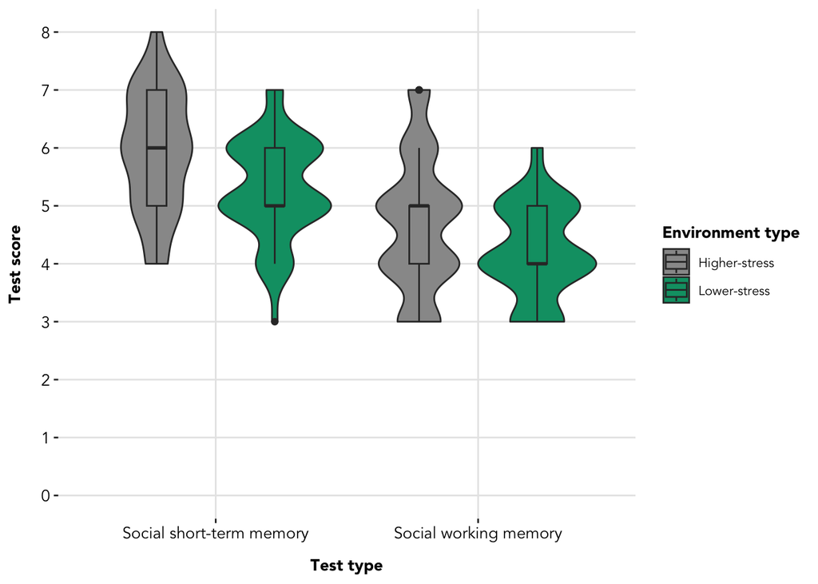

## Power analyses

Power analyses were carried out using the `faux` package in R (DeBruine, 2021). Using the dataset described above as a reference, 25,000 simulated sample datasets were created for each of the two memory test types. This was done through sampling different simulated populations of test scores (`test_score`) that varied according to environment type (`environment`), sample size (15, 20, 25, 30, 35) and the effect of the higher-stress environment on test scores, which differed for social short-term memory scores (0.2, 0.4, 0.841, 1, 1.2) and social working memory scores (0.25, 0.499, 0.75, 1, 1.25).

The following model was run on each of the 25,000 simulated sample datasets; treatment contrasts where used for the `environment` variable, with the lower-stress environment being the baseline or reference category.

```
lm(test_score ~ environment, data = data)
```

The power analyses reported below were calculated as the frequency of the 25,000 *p*-values that were less than 0.05 for the *b*-coefficient that compared test scores from the higher-stress environment to test scores from the lower-stress environment.

### Social short-term memory

Below is the power analysis result with social short-term memory as the outcome. Results suggest that 25 participants per environment would give sufficient power (0.81) to detect mean differences of at least 0.841 (the effect observed in our previous study) between the higher and lower stress environments.

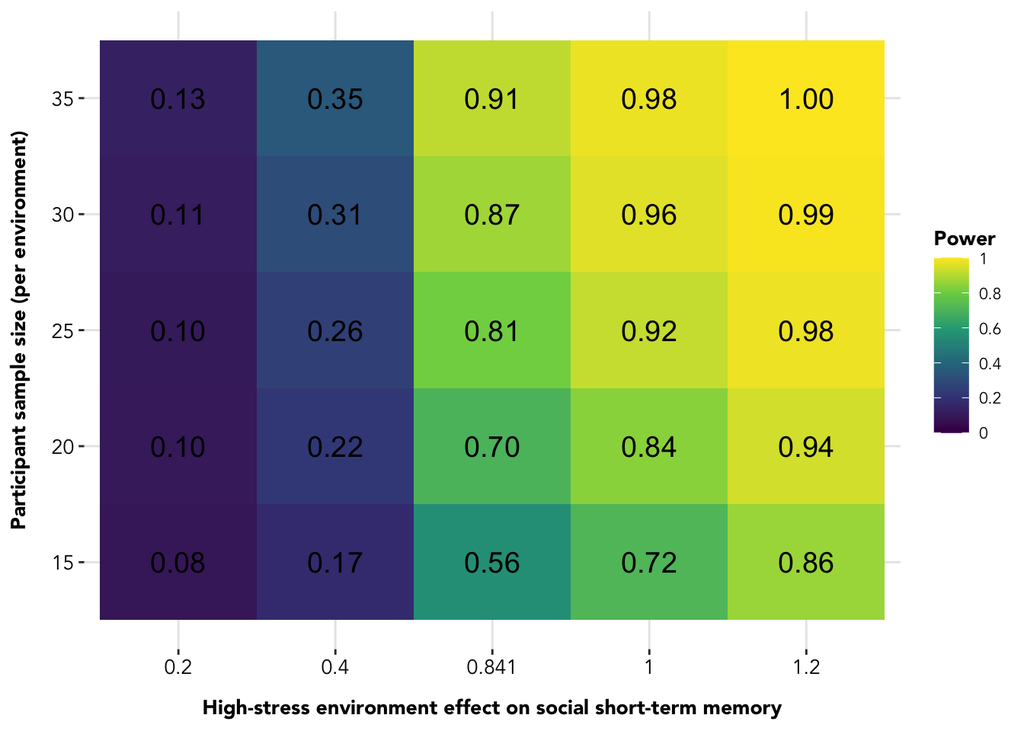

### Social working memory

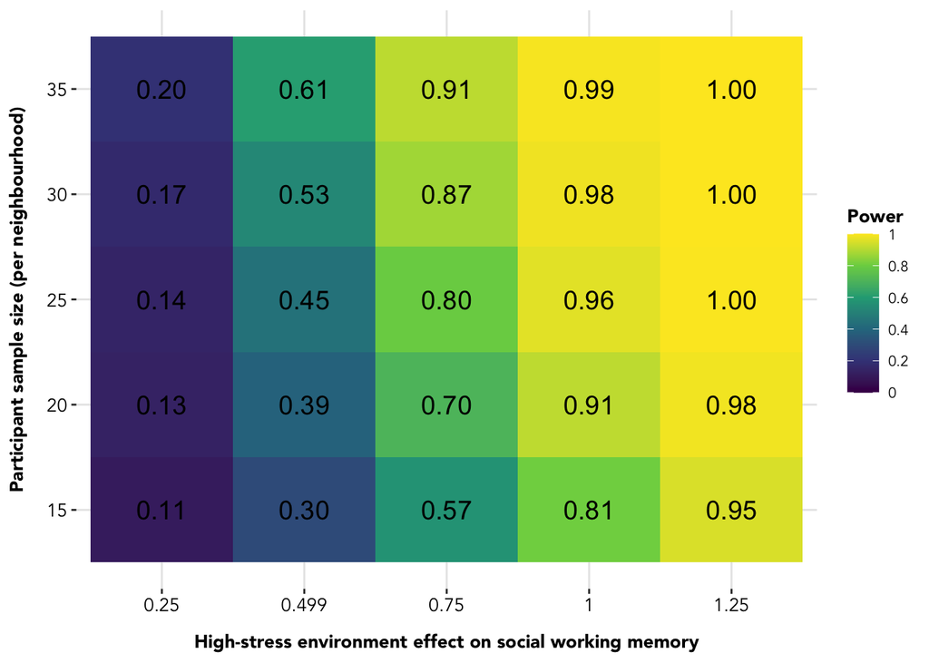

## Citations

DeBruine L (2021). *faux: Simulation for Factorial Designs*. doi: 10.5281/zenodo.2669586, R package version 1.1.0, https://debruine.github.io/faux/.